# Project R

Legrand, Hu, Stintzi

2025-10-22

# Project NYC Airbnb - Analyzing the Rental Market

### Projet Goal :

Your data analyst team has been hired to study the Airbnb market in New York City. Using a public dataset, you must analyze price trends, the geographic distribution of listings, and the factors that influence rental prices. The project will culminate in the creation of a regression model to predict the price of a rental and an interactive map to visualize your findings.

## Step 1 : Data Cleaning and Preparation

- Handling Temporal Data: The column last_review has been converted to date format in order to be able to perform temporal analyses.
- Treating Informative NAs: The missing values in reviews_per_month have been replaced with 0, as they correspond to homes without reviews.
- Cleaning the Price Column: Ads with a price equal to 0 have been removed, because they are not realistic.
- Removing Irrelevant Columns: The id, host_id and host_name columns have been removed because they are not useful for general analysis.

Handling Temporal Data: The last_review column is in text format. Convert it to a proper date format using the lubridate package.

Treating Informative NA s: The last_review and reviews_per_month columns have NA s for listings with no reviews. Replace the .NA s in reviews_per_month with a proper number.

Aperçu du jeu de données nettoyé

| name | neighbourhood_group | neighbourhood | latitude | longitude | room_type | price | minimum_nights | number_of_reviews | last_review | reviews_per_month | calculated_host_listings_count | availability_365 |
| --- | --- | --- | --- | --- | --- | --- | --- | --- | --- | --- | --- | --- |
| Clean & quiet apt home by the park | Brooklyn | Kensington | 40.64749 | -73.97237 | Private room | 149 | 1 | 9 | 2018-10-19 | 0.21 | 6 | 365 |
| Skylit Midtown Castle | Manhattan | Midtown | 40.75362 | -73.98377 | Entire home/apt | 225 | 1 | 45 | 2019-05-21 | 0.38 | 2 | 355 |
| THE VILLAGE OF HARLEM….NEW YORK ! | Manhattan | Harlem | 40.80902 | -73.94190 | Private room | 150 | 3 | 0 | NA | 0.00 | 1 | 365 |
| Cozy Entire Floor of Brownstone | Brooklyn | Clinton Hill | 40.68514 | -73.95976 | Entire home/apt | 89 | 1 | 270 | 2019-07-05 | 4.64 | 1 | 194 |
| Entire Apt: Spacious Studio/Loft by central park | Manhattan | East Harlem | 40.79851 | -73.94399 | Entire home/apt | 80 | 10 | 9 | 2018-11-19 | 0.10 | 1 | 0 |
| Large Cozy 1 BR Apartment In Midtown East | Manhattan | Murray Hill | 40.74767 | -73.97500 | Entire home/apt | 200 | 3 | 74 | 2019-06-22 | 0.59 | 1 | 129 |

## Step 2 : Feature Transformation and Engineering

### Logarithmic Price Transformation

- The variable price was transformed into price_log using a logarithmic transformation

Verify the difference between price and price_log

```
##    Min. 1st Qu.  Median    Mean 3rd Qu.    Max.
##    10.0    69.0   106.0   152.8   175.0 10000.0
```

```
##    Min. 1st Qu.  Median    Mean 3rd Qu.    Max.
##   2.398   4.248   4.673   4.738   5.170   9.210
```

### Creating a Recency Feature

- A new variable days_since_last_review has been created to know how many days have passed since the last review

### Simplifying Neighborhoods

- The neighborhood analysis was checked to identify the most suitable column for visualizations.

```
##
##         Bronx      Brooklyn     Manhattan        Queens Staten Island
##          1090         20095         21660          5666           373
```

```
## [1] 221
```

### Encoding Room Types

- The room_type variable has been converted into a factor so that it is recognized as a categorical variable by R.

```
##  Factor w/ 3 levels "Entire home/apt",..: 2 1 2 1 1 1 2 2 2 1 ...
```

```
## [1] "Entire home/apt" "Private room"    "Shared room"
```

## Step 3 : Visualization and Exploration

### Creation of the interactive map

[interactive chart not shown]

Because there’s more than 44.000 AirBnB in New York City, the map lag in the area.

### Price distribution by borought

- The distribution of prices (on the logarithmic scale) was compared between the different neighborhoods to visualize cost differences.

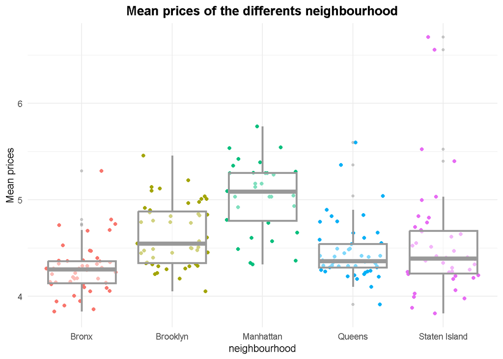

On this graphic, the points are the mean price of each neighbourhood. The boxplots are the price mean of every neighbourhood_group, based on the price mean of the neighbourhood

### Distribution of listing type

- Distribution of Listing Types: A graph shows the number of dwellings by room type (room_type), revealing that the majority of rentals are apartments or entire houses.

[figure not shown]

As we can see, most of the AirBnB booked are the entire Home / apartment. This is quite logical because it’s what AirBnB push on

### Relationship between availability and Reviews

- Graphs explore the relationship between availability (availability_365) and number of reviews (number_of_reviews) for each borough, facilitating the identification of trends.

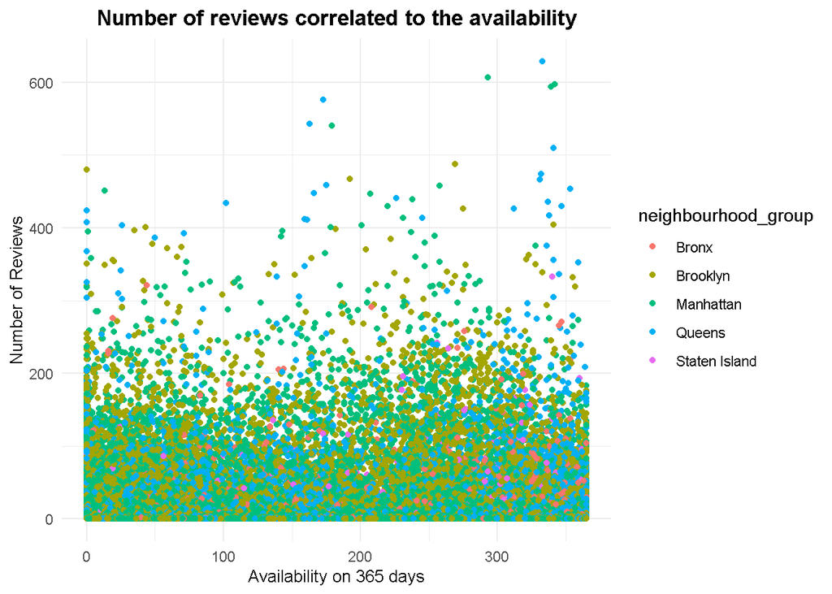

As we can see, there’s too much element to be clear. We will now separate by neighbourhood

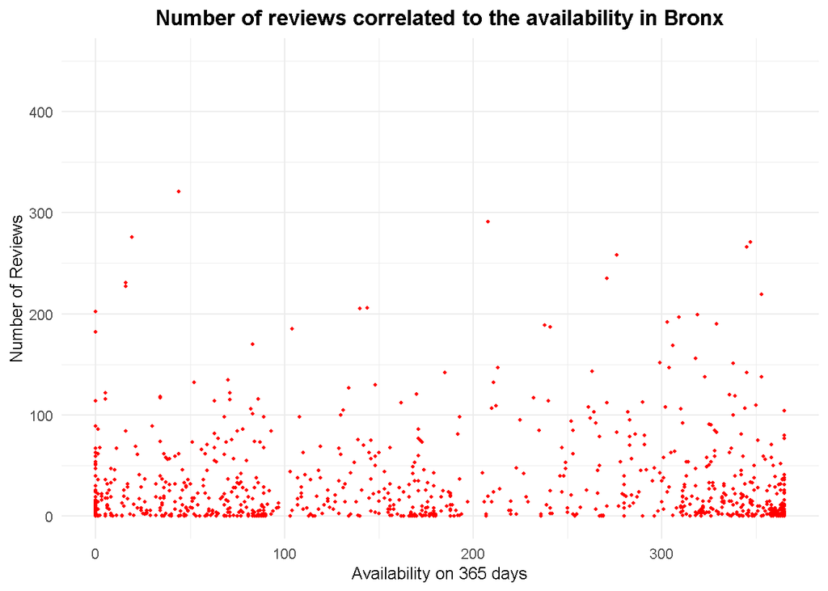

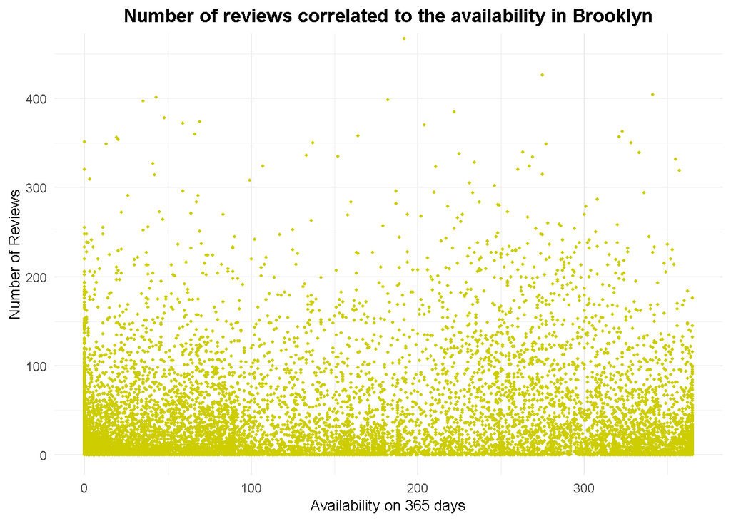

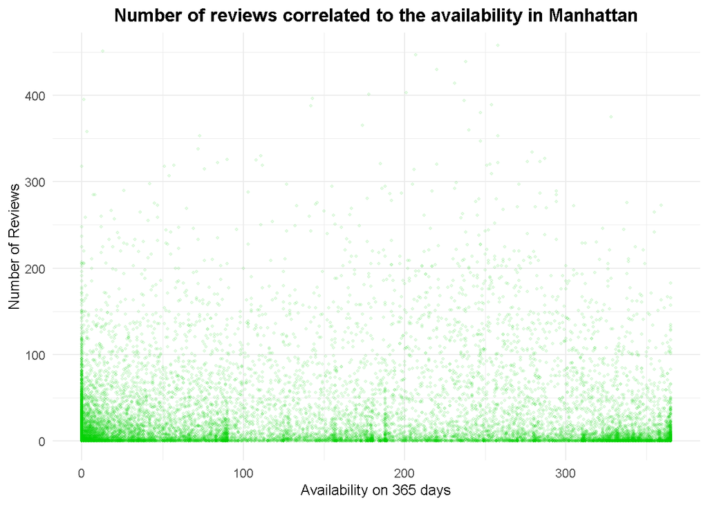

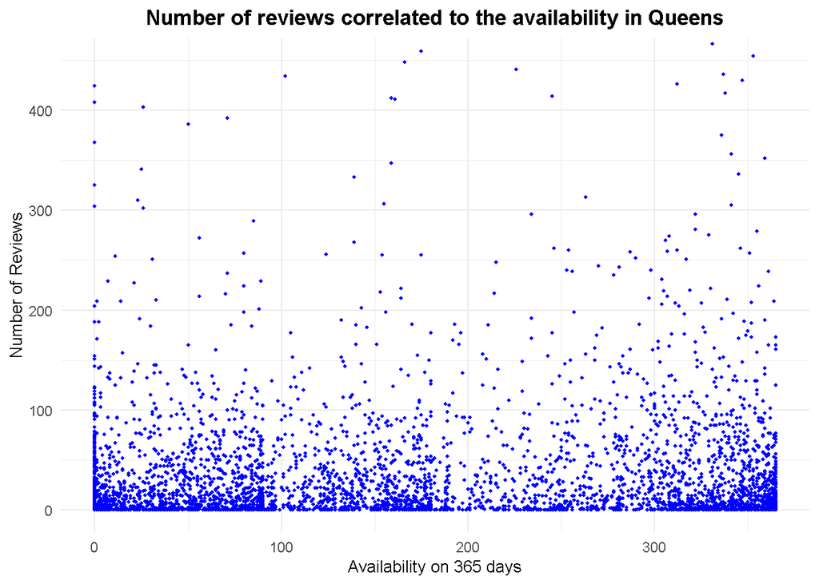

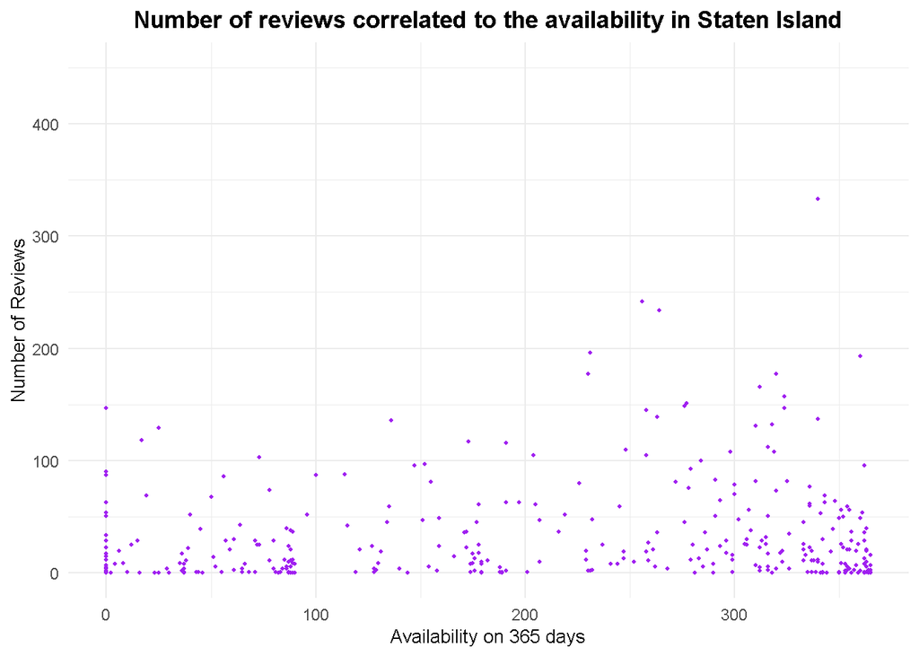

As we can see, it’s still not enough to have a good view on all the data we want, especially in Brooklyn, Manhattan and Queens. So we will cut the graphs in 2, in order to make it easier to read.

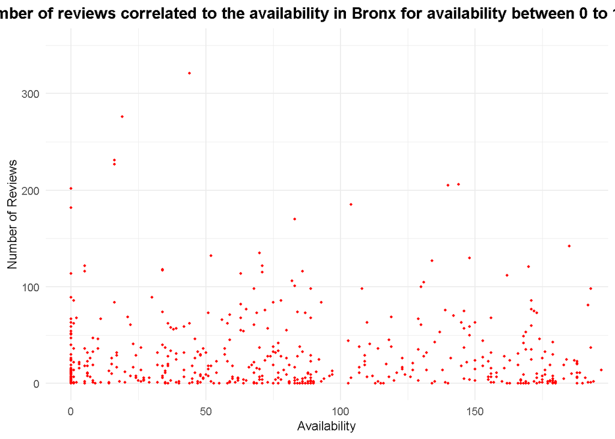

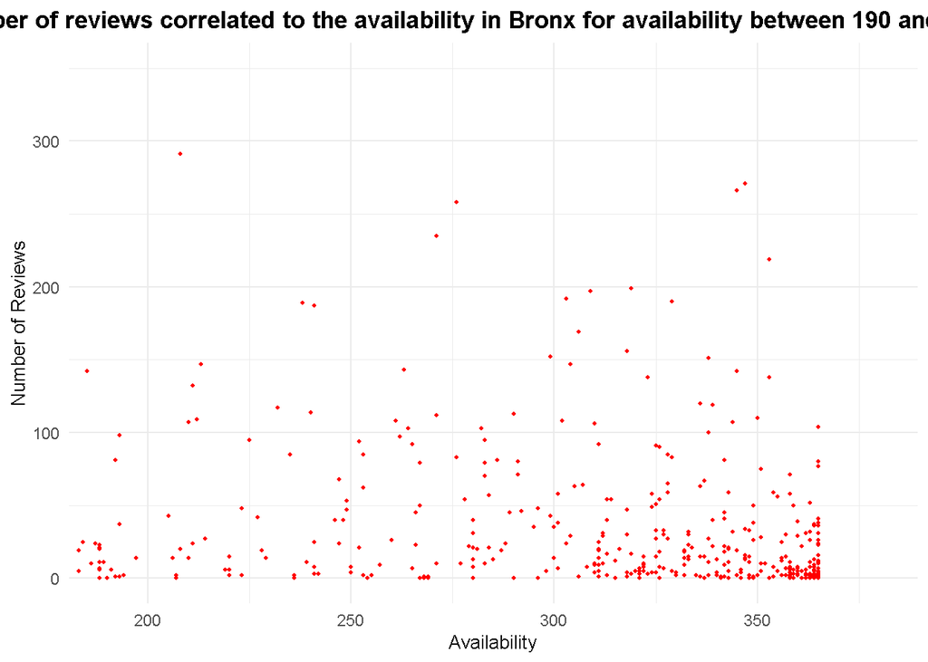

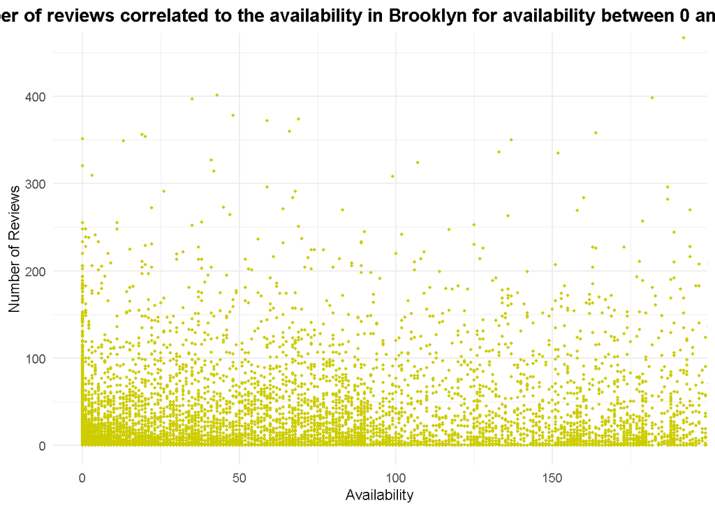

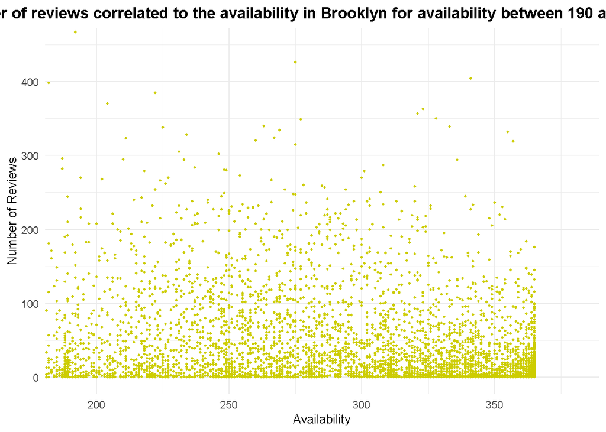

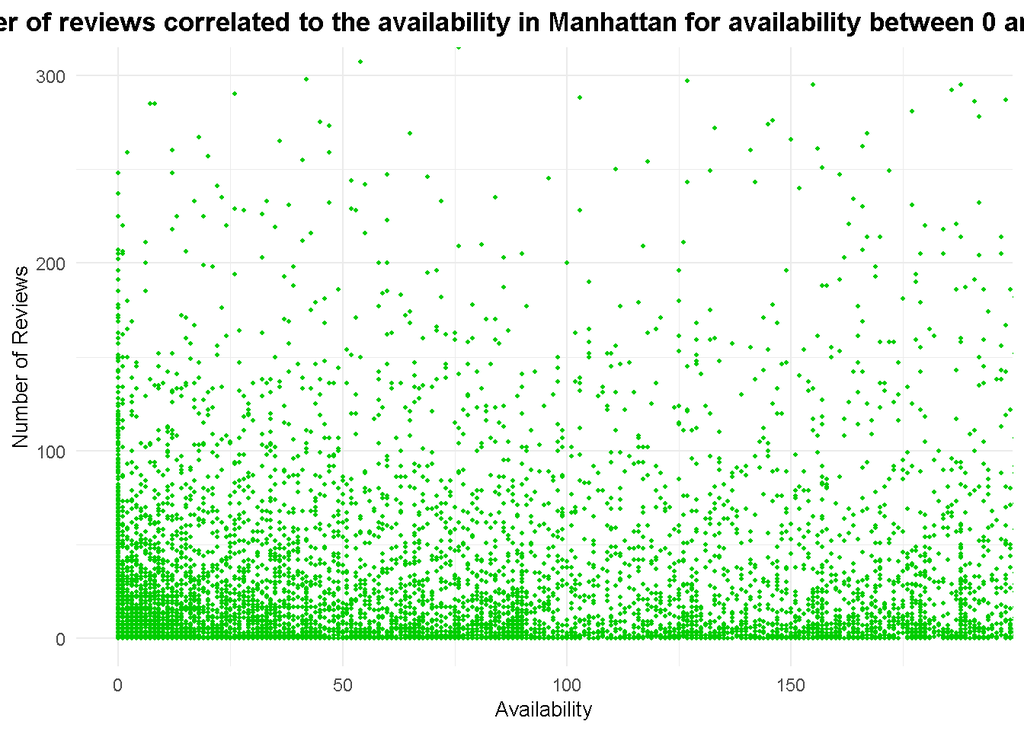

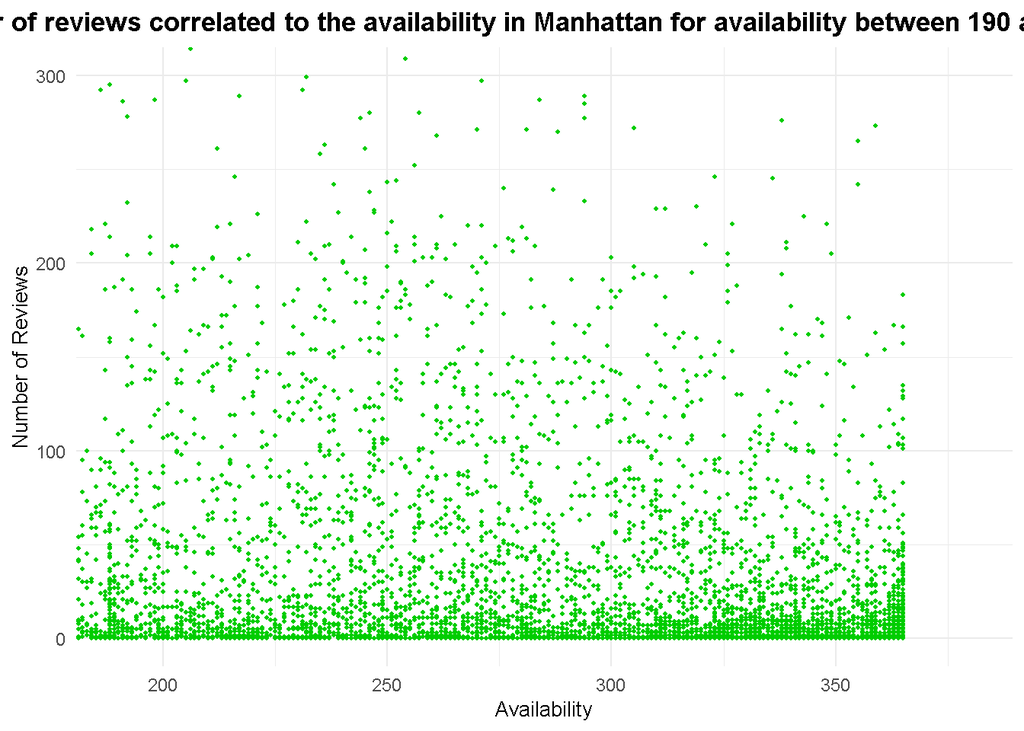

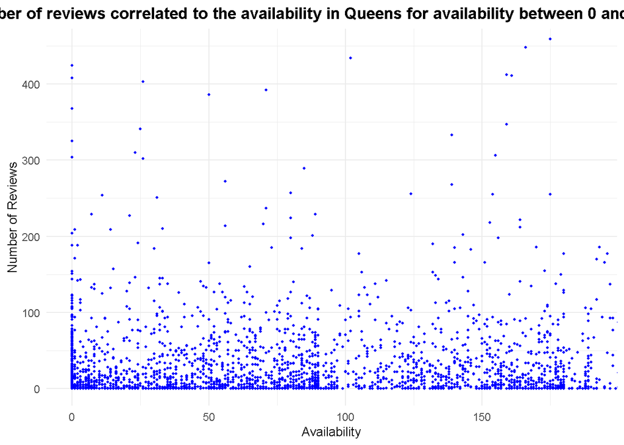

[figure not shown]

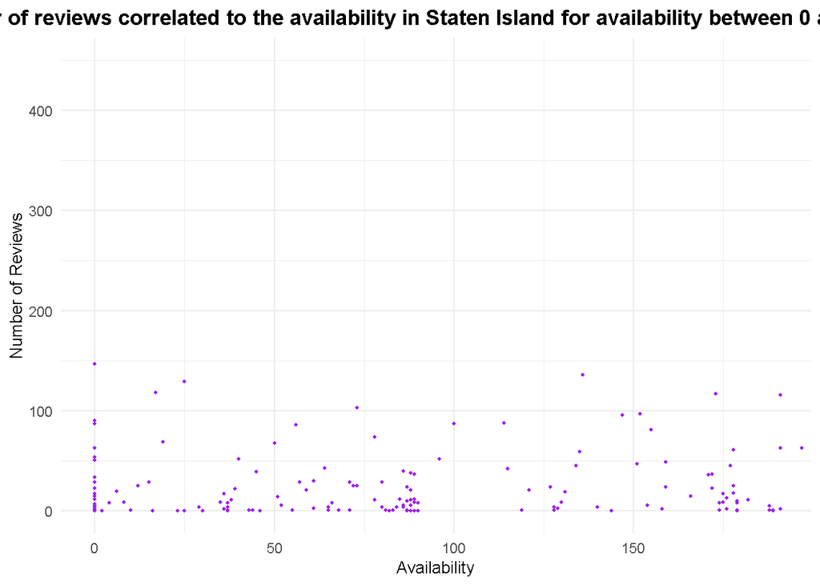

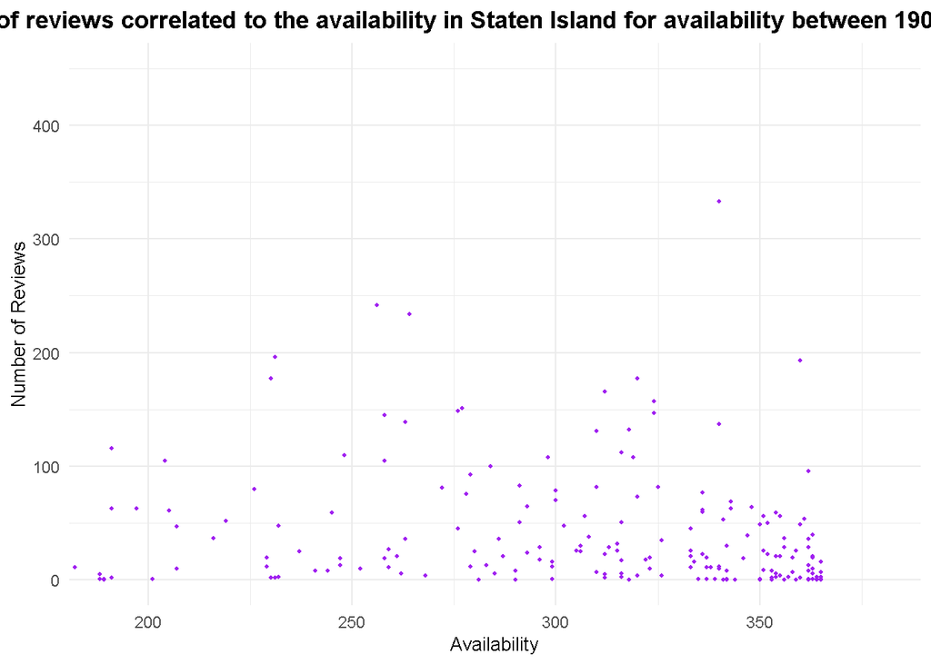

Now, the graphs looks much easier to understand.

### Comparaison entre price et minimum night

- Additional charts analyze the relationship between price and minimum nights, as well as price and number of reviews, to better understand the Airbnb market.

[figure not shown]

As we can see, some AirBnB asks for too much nights, which makes it not interesting (and not possible). If we were staff members form AirBnB, we would have looked at them in order to be sure everything is alright with theses announcement. We will now look much closer on those who requires less than a year of minimum nights, in order to have a better view of them.

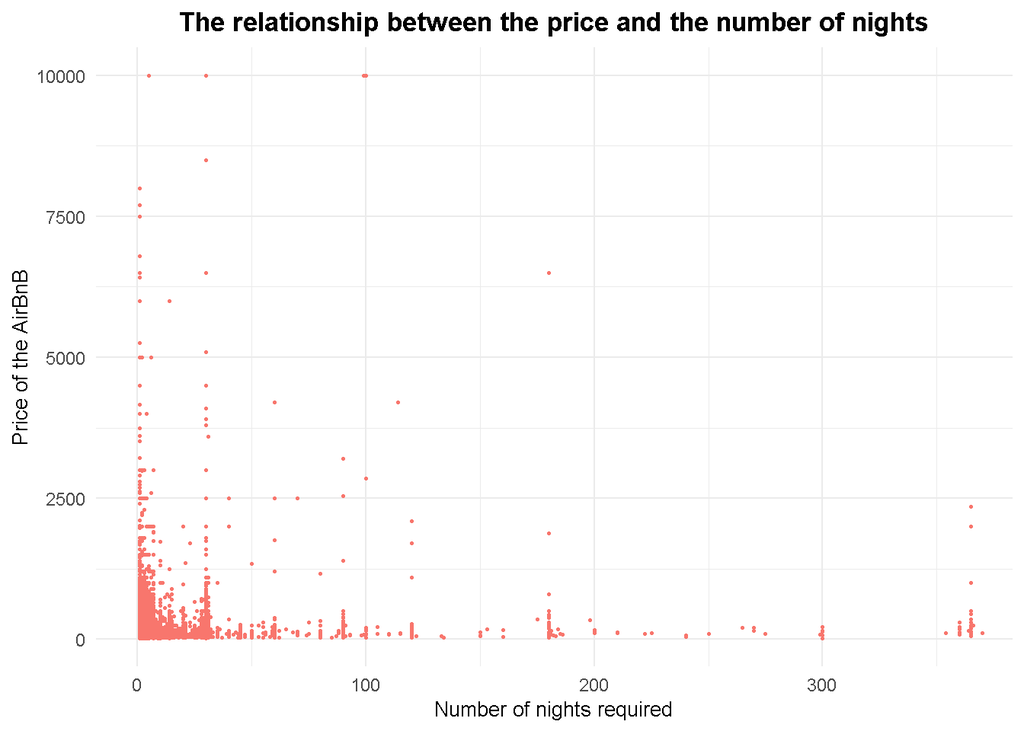

And now, the relationships for the flats that requires less than 100 days in it :

[figure not shown]

### Correlation between the number of review and the price of AirBnB

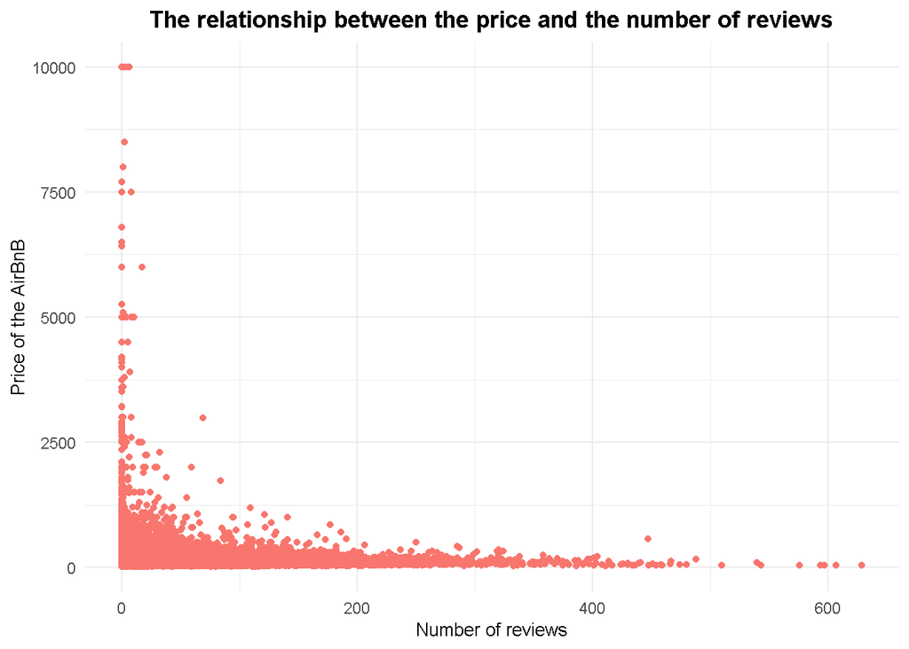

As we can see, the less the price is, the more reviews there is. Cheap AirBnB are more attractive.

## Step 4 : Modeling and Prediction (Data Science)

### Linear Regression Model

- A linear regression model was trained to predict the price (log-transformed) as a function of neighborhood (neighbourhood_group), room type (room_type) and number of reviews (number_of_reviews).

```
##
## Call:
## lm(formula = log1p(price) ~ neighbourhood_group + room_type +
##     number_of_reviews, data = Clean_train)
##
## Residuals:
##     Min      1Q  Median      3Q     Max
## -2.9280 -0.3102 -0.0388  0.2447  5.0881
##
## Coefficients:
##                                    Estimate Std. Error  t value Pr(>|t|)
## (Intercept)                       4.794e+00  1.585e-02  302.556  < 2e-16 ***
## neighbourhood_groupBrooklyn       2.066e-01  1.592e-02   12.979  < 2e-16 ***
## neighbourhood_groupManhattan      5.314e-01  1.592e-02   33.374  < 2e-16 ***
## neighbourhood_groupQueens         1.017e-01  1.691e-02    6.014 1.83e-09 ***
## neighbourhood_groupStaten Island  2.173e-02  3.067e-02    0.708    0.479
## room_typePrivate room            -7.730e-01  4.762e-03 -162.330  < 2e-16 ***
## room_typeShared room             -1.124e+00  1.539e-02  -73.006  < 2e-16 ***
## number_of_reviews                -3.989e-04  5.199e-05   -7.673 1.71e-14 ***
## ---
## Signif. codes:  0 '***' 0.001 '**' 0.01 '*' 0.05 '.' 0.1 ' ' 1
##
## Residual standard error: 0.5112 on 48876 degrees of freedom
## Multiple R-squared:  0.454,  Adjusted R-squared:  0.4539
## F-statistic:  5806 on 7 and 48876 DF,  p-value: < 2.2e-16
```

### Decision Tree Model

- A regression tree was built using rpart to visualize how decisions on price are structured.

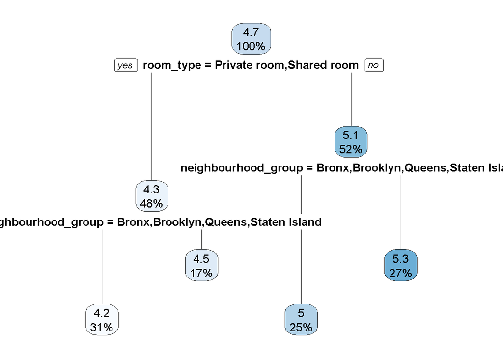

Now we see that 31% of people take shared or private room that cost 66$ and 17% for 89$ And 25% of people take home or apartment for 147$ and 27% of them take it for 200$

### Model Evaluation

- Predictions were transformed back to the original scale and RMSE was calculated to evaluate model accuracy.

```
## [1] 231.8586
```

```
## [1] 232.107
```

Both models have an average error of about $230, which is reasonable given the high variability of Airbnb prices in New York.

### Interpretation

The model shows that Airbnb prices in New York City vary significantly depending on the neighborhood and type of accommodation. Locations in Manhattan and Brooklyn are, on average, much more expensive than those in the Bronx. Conversely, “Private Rooms” and “Shared Rooms” are considerably cheaper than “Entire Homes.” The number of reviews has a slight negative effect on price, suggesting that older or more popular listings tend to be slightly less expensive. Overall, these variables explain approximately 45% of the log-transformed price variation, making this a simple yet relevant model for an initial analysis of pricing factors.